# Chapter3

# Logistic Regression

**The following dataset is being used for the purpose of this statistical analysis: *alc*. The dataset is the result of the research “Student Alcohol Cumsumption, available through AVI Machine Learning**

**It is the objective of this report to analyse the data through R, with a concise explanation of each step and codes used.**

**1) Structure of the Data** The following code is used to analyse the structure of the data, such as how many variables and total number of observations. Total: 382x35

```
## [1] 382  35
```

```
## 'data.frame':    382 obs. of  35 variables:
##  $ school    : Factor w/ 2 levels "GP","MS": 1 1 1 1 1 1 1 1 1 1 ...
##  $ sex       : Factor w/ 2 levels "F","M": 1 1 1 1 1 2 2 1 2 2 ...
##  $ age       : int  18 17 15 15 16 16 16 17 15 15 ...
##  $ address   : Factor w/ 2 levels "R","U": 2 2 2 2 2 2 2 2 2 2 ...
##  $ famsize   : Factor w/ 2 levels "GT3","LE3": 1 1 2 1 1 2 2 1 2 1 ...
##  $ Pstatus   : Factor w/ 2 levels "A","T": 1 2 2 2 2 2 2 1 1 2 ...
##  $ Medu      : int  4 1 1 4 3 4 2 4 3 3 ...
##  $ Fedu      : int  4 1 1 2 3 3 2 4 2 4 ...
##  $ Mjob      : Factor w/ 5 levels "at_home","health",..: 1 1 1 2 3 4 3 3 4 3 ...
##  $ Fjob      : Factor w/ 5 levels "at_home","health",..: 5 3 3 4 3 3 3 5 3 3 ...
##  $ reason    : Factor w/ 4 levels "course","home",..: 1 1 3 2 2 4 2 2 2 2 ...
##  $ nursery   : Factor w/ 2 levels "no","yes": 2 1 2 2 2 2 2 2 2 2 ...
##  $ internet  : Factor w/ 2 levels "no","yes": 1 2 2 2 1 2 2 1 2 2 ...
##  $ guardian  : Factor w/ 3 levels "father","mother",..: 2 1 2 2 1 2 2 2 2 2 ...
```

[output cut: 21 more lines]

**Dimensions of the Data** For the following exercise, three graphs represent three variables that directly impact the student’s comsumption of alcohol.

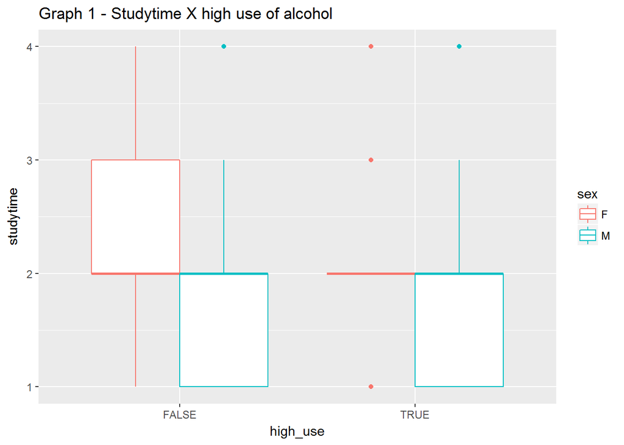

*Family Relations x Alcohol COnsumption*

The following graph shows the relationship between Family relationship and high use of alcohol. This supports the assumption that family relationships are determinant on the quantity of alcohol being consumed by the student (more as the relationship worsens)

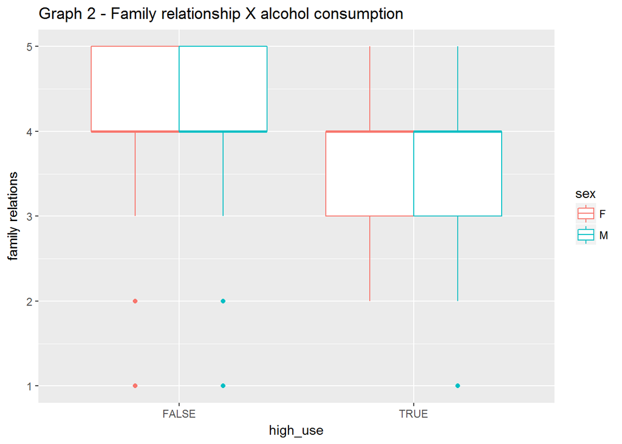

*Free Time x Alcohol COnsumption*

The following graph shows the relationship between free time and alcohol abuse. On this case, specially on girls, the statement that the higher amount of free time influences negatively on the amount of alcohol being consumed can be considered true.

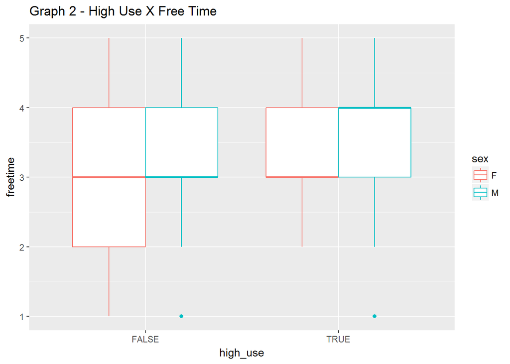

**Logistic Regression**

This model predicts the probability of free time, family relations, sex and studytime when related to the high use of alcohol.

```
##
## Call:
## glm(formula = high_use ~ freetime + famrel + sex + studytime,
##     family = "binomial", data = alc)
##
## Deviance Residuals:
##     Min       1Q   Median       3Q      Max
## -1.7003  -0.8583  -0.6046   1.1678   2.1170
##
## Coefficients:
##             Estimate Std. Error z value Pr(>|z|)
## (Intercept)   0.1308     0.6726   0.194  0.84583
## freetime      0.3101     0.1257   2.467  0.01362 *
## famrel       -0.3847     0.1285  -2.994  0.00275 **
## sexM          0.6371     0.2518   2.530  0.01141 *
## studytime    -0.4468     0.1573  -2.840  0.00450 **
## ---
## Signif. codes:  0 '***' 0.001 '**' 0.01 '*' 0.05 '.' 0.1 ' ' 1
##
## (Dispersion parameter for binomial family taken to be 1)
##
##     Null deviance: 462.21  on 381  degrees of freedom
## Residual deviance: 423.71  on 377  degrees of freedom
## AIC: 433.71
##
## Number of Fisher Scoring iterations: 4
```

According to the following statement, we an agree that free time and family relations do impact on high use of alcohol.

```
## (Intercept)    freetime      famrel        sexM   studytime
##   0.1307898   0.3101352  -0.3847478   0.6370787  -0.4468016
```

*Data Prediction*

Verifying the prediction power of our model when new data is added, and its tendency or not to be an avid drinker. The prediction should be done through binary form, with the set value of 0.5 as a measure. Any value higher than 0.5 appoints the new piece of data as probably being a high consumer of alcohol.

```
##         prediction
## high_use FALSE TRUE
##    FALSE   250   20
##    TRUE     92   20
```

*Prediction Graph*

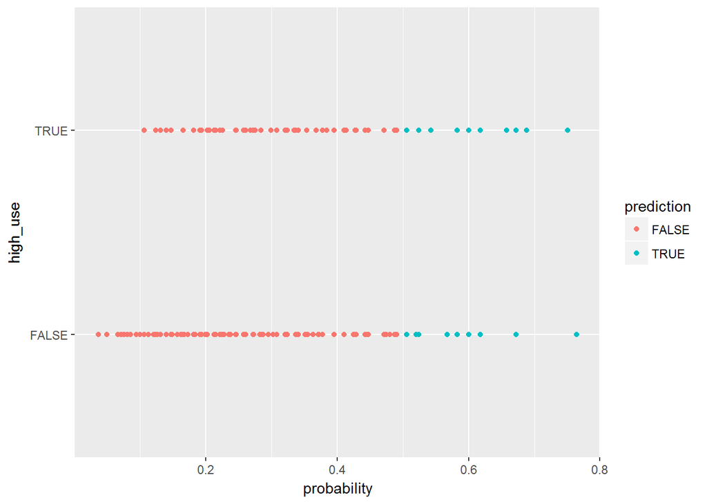

```
##         prediction
## high_use      FALSE       TRUE        Sum
##    FALSE 0.65445026 0.05235602 0.70680628
##    TRUE  0.24083770 0.05235602 0.29319372
##    Sum   0.89528796 0.10471204 1.00000000
```

*Testing Errors*

The current testing error value of this data is 29%. This means that 29% of the predictions could not be correct.

```
## [1] 0.2931937
```